# [금융 빅데이터 전문가 과정] 실습자료 RNN

이번 실습은 Keras를 이용하여 RNN 구조를 구현해보는 것이 목표입니다. 주가지수 KOSPI 종가의 5일 후 예측하는 모델을 구현해봅니다.

## 0. Module & Parameter

먼저 분석에 필요한 파이썬 모듈(Module)을 불러오고, 분석에 필요한 옵션을 설정합니다.

#### 0.1 모듈 불러오기

이번 실습에서는 아래와 같은 모듈을 사용하였습니다.

```python
!pip install --upgrade tensorflow==2.0.0
```

```python
import os
import pandas as pd
import numpy as np
import matplotlib.pyplot as plt
from datetime import datetime
import tensorflow as tf
from tensorflow import keras
from tensorflow.keras.models import Model
from tensorflow.keras.layers import RNN, Dense, Input
from tensorflow.keras.optimizers import RMSprop
```

```python
# 실수를 출력하는 함수를 설정할 수 있습니다.
pd.options.display.float_format = lambda x:f'{x:.4f}'
```

```python
# 모듈에 ".__version__"을 이용하면 버전을 확인할 수 있다.
print('tensorflow version :', tf.__version__)
```

```
tensorflow version : 2.0.0
```

### 0.2 환경 및 조건 설정

분석 시 필요한 조건을 설정합니다. **DIRHOME** 객체는 데이터의 위치를 설정합니다. **AHEAD** 객체는 예측을 하는시점과 예측일의 간격을 수치형으로 설정합니다. **yVar** 객체는 목표변수(target variable)를 설정합니다.

```python
DIRHOME = 'G:/내 드라이브/01_BEGAS/2020_금융교육자료/05_실습자료/RNN/dat/'
AHEAD = 5
yVar = 'ks11_close'
```

## 1. 데이터 준비하기

실습에 사용할 데이터를 로드하고, EDA(Exploratory Data Analysis)를 진행합니다.

### 1.1 원데이터 불러오기

데이터는 **FinanceDataReader**모듈에서 데이터를 수집하였고, 사용기간은 *'2008-01-01'~'2020-06-30'* 중 주말을 제외하고 사용합니다. 주말을 제외한 이유는 주말에 거래가 일어나지 않기 때문입니다. 결측치는 Cubic Spline을 이용하여 보간하였습니다. 특성(Featrue) 수는 날짜를 포함하여 160 개이고, 관측치(row) 수는 3,261 개입니다. 일부 특성(feature)의 마지막 값들을 pandas의 tail() 메소드를 이용하여 살펴봅니다.

```python
rawDF = pd.read_csv(os.path.join(DIRHOME, 'BigdataAcademy_Finance.txt'),sep ='|')
rawDF['date'] = pd.to_datetime(rawDF['date'])
print(rawDF.shape)
```

```
(3261, 160)
```

```python
rawDF[['date', 'ks11_close', 'csi300_high', 'usdjpy_open_x', 'hg_open', 'usdjpy_change_y', 'hsi_open', 'vix_change']].tail(7)
```

|  | date | ks11_close | csi300_high | usdjpy_open_x | hg_open | usdjpy_change_y | hsi_open | vix_change |
| --- | --- | --- | --- | --- | --- | --- | --- | --- |
| 3254 | 2020-06-22 | 2126.7300 | 4126.9400 | 106.9000 | 2.6020 | 0.0000 | 24528.5300 | -0.0954 |
| 3255 | 2020-06-23 | 2131.2400 | 4124.7300 | 106.9100 | 2.6580 | -0.0034 | 24541.4400 | -0.0126 |
| 3256 | 2020-06-24 | 2161.5100 | 4144.6800 | 106.5200 | 2.6520 | 0.0048 | 25034.8700 | 0.0787 |
| 3257 | 2020-06-25 | 2112.3700 | 4146.4662 | 107.0600 | 2.6450 | 0.0015 | 25004.4096 | -0.0479 |
| 3258 | 2020-06-26 | 2134.6500 | 4136.0408 | 107.2400 | 2.6650 | 0.0002 | 24697.9800 | 0.0779 |
| 3259 | 2020-06-29 | 2093.4800 | 4137.3700 | 107.1900 | 2.6510 | 0.0032 | 24627.6400 | -0.0849 |
| 3260 | 2020-06-30 | 2108.3300 | 4174.4200 | 107.5800 | 2.6910 | 0.0039 | 24468.2400 | -0.0425 |

```python
# 데이터 타입 확인
rawDF.dtypes
```

```
date             datetime64[ns]
ks11_close              float64
ks11_open               float64
ks11_high               float64
ks11_low                float64
                      ...
usdrub_close            float64
usdrub_open             float64
usdrub_high             float64
usdrub_low              float64
usdrub_change           float64
Length: 160, dtype: object
```

```python
yDF = rawDF[['date', yVar]]
yDF.head()
```

|  | date | ks11_close |
| --- | --- | --- |
| 0 | 2008-01-01 | 1865.1706 |
| 1 | 2008-01-02 | 1853.4500 |
| 2 | 2008-01-03 | 1852.7300 |
| 3 | 2008-01-04 | 1863.9000 |
| 4 | 2008-01-07 | 1831.1400 |

### 1.2 EDA

특성들의 통계량을 구하고, 특성(feature)와 목표변수(target varaible)를 시각화해봅니다.

#### 통계량 확인

```python
statDF = rawDF.describe().transpose()
statDF.iloc[np.random.choice(statDF.shape[0], 7), :]
```

|  | count | mean | std | min | 25% | 50% | 75% | max |
| --- | --- | --- | --- | --- | --- | --- | --- | --- |
| gc_close | 3261.0000 | 1318.7817 | 236.9606 | 704.9000 | 1213.3000 | 1320.6000 | 1449.2000 | 1899.6104 |
| audusd_change | 3261.0000 | -0.0000 | 0.0086 | -0.0733 | -0.0041 | 0.0001 | 0.0043 | 0.0858 |
| us500_open | 3261.0000 | 1862.4144 | 666.1511 | 679.2800 | 1293.1600 | 1860.0900 | 2392.4400 | 3380.4500 |
| kq11_high | 3261.0000 | 596.6585 | 114.9454 | 272.6800 | 512.9000 | 565.0100 | 678.1500 | 932.0100 |
| vix_volume | 3261.0000 | 0.0000 | 0.0000 | 0.0000 | 0.0000 | 0.0000 | 0.0000 | 0.0000 |
| jp225_high | 3261.0000 | 15294.5382 | 5039.3156 | 7100.7700 | 10077.2200 | 15163.0600 | 19941.6400 | 24448.0700 |
| si_close | 3261.0000 | 20.2451 | 6.7112 | 8.7900 | 16.2630 | 17.9150 | 21.1460 | 48.5840 |

#### 목표변수(Target Variable) 시각화

여기서는 하나의 예시로 예측하려고 하는 코스피(KOSPI)를 시각화합니다. 예측에 사용되는 특성(feature)들도 시각화해보길 권장합니다.

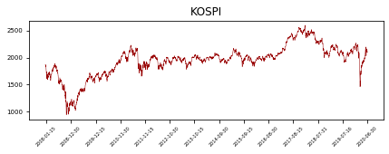

```python
plt.rcParams["figure.figsize"] = (7,2)
# plt.rcParams["figure.dpi"] = 200

plt.plot(rawDF[yVar], linewidth = 0.5, color = (153/256, 0/256, 0/256))
idxL = [ii for ii in range(rawDF.shape[0]-1, 0, -250)]
idxL.sort()
plt.xticks(idxL, rawDF['date'][idxL].astype('str'), rotation = 45)
plt.tick_params(axis = 'x', labelsize = 5)
plt.tick_params(axis = 'y', labelsize = 7)
plt.title('KOSPI')
plt.show()
```

#### 특성(feature) 시각화

랜덤하게 선정한 한 특성(feature)를 시각화합니다.

```python
xVar = rawDF.columns[54]
print(xVar)
```

```
hsi_change
```

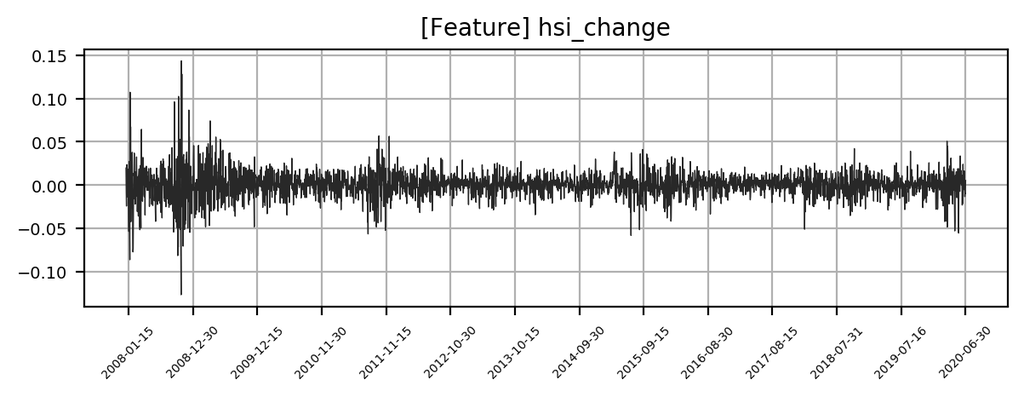

```python
plt.rcParams["figure.figsize"] = (7,2)
plt.rcParams["figure.dpi"] = 200
plt.rcParams['axes.grid'] = True
plt.plot(rawDF[xVar], linewidth = 0.5, color = (40/256, 40/256, 40/256))
idxL = [ii for ii in range(rawDF.shape[0]-1, 0, -250)]
idxL.sort()
plt.xticks(idxL, rawDF['date'][idxL].astype('str'), rotation = 45)
plt.tick_params(axis = 'x', labelsize = 5)
plt.tick_params(axis = 'y', labelsize = 7)
plt.title( '[Feature] ' + xVar, fontsize = 10)
plt.show()
```

## 2. 데이터 전처리

기존에 결측치를 cubic Spline을 이용하여 보간(interpolate)한 데이터를 이용하여, 모델학습에 필요한 데이터 조건 및 형태로 변환합니다.

### 2.1 차분(difference)

차분을 이용해 시점 간 차이를 구해 추제를 제거합니다. 식은 아래와 같습니다. 추세를 제거하지 않은 원데이터를 사용해보는 것도 하나의 방법입니다.

$$ X^{'}_{t+k} = X_{t+k} - X_{t} $$

```python
print('[rawDF Before set index]')
rawDF.head(3)
```

```
[rawDF Before set index]
```

|  | date | ks11_close | ks11_open | ks11_high | ks11_low | ks11_volume | ks11_change | kq11_close | kq11_open | kq11_high | ... | audusd_close | audusd_open | audusd_high | audusd_low | audusd_change | usdrub_close | usdrub_open | usdrub_high | usdrub_low | usdrub_change |
| --- | --- | --- | --- | --- | --- | --- | --- | --- | --- | --- | --- | --- | --- | --- | --- | --- | --- | --- | --- | --- | --- |
| 0 | 2008-01-01 | 1865.1706 | 1919.8203 | 1915.1760 | 1878.5871 | 245508865.1529 | -0.0291 | 704.7320 | 711.9592 | 713.1675 | ... | 0.8763 | 0.8743 | 0.8789 | 0.8735 | 0.0005 | 24.5730 | 24.5730 | 24.5870 | 24.5610 | -0.0003 |
| 1 | 2008-01-02 | 1853.4500 | 1891.4500 | 1892.5000 | 1852.7800 | 247090000.0000 | -0.0230 | 707.1200 | 709.0700 | 713.5200 | ... | 0.8833 | 0.8760 | 0.8838 | 0.8756 | 0.0080 | 24.4430 | 24.5660 | 24.5810 | 24.4190 | -0.0053 |
| 2 | 2008-01-03 | 1852.7300 | 1834.4400 | 1858.0800 | 1821.6100 | 253670000.0000 | -0.0004 | 714.0000 | 702.5700 | 714.0600 | ... | 0.8803 | 0.8836 | 0.8853 | 0.8785 | -0.0034 | 24.4360 | 24.4460 | 24.4820 | 24.3970 | -0.0003 |

3 rows × 160 columns

특성 ['date']를 제외한 나머지 변수들을 차분하기 위해서 임시로 특성 ['date']를 인덱스로 바꾼 후 변환해준다.  
**pandas**모듈의 **diff** 메소드를 이용하여 5일 차분을 진행합니다. 위 식에서 (t+k)가 5보다 작을 경우 계산가능한 (t)시점의 값이 없어서 차분값이 존재하지 않게 된다. 5일 차분 시 6번째 행(row)부터 1번째 행(row)과 계산이 가능하므로 번째 row까지는 차분값이 없으므로 5번째값까지는 해당 행은 제거해준다.

```python
rawDF = rawDF.set_index('date')
print('[rawDF After set index]')
rawDF.head(3)
```

```
[rawDF After set index]
```

| date | ks11_close | ks11_open | ks11_high | ks11_low | ks11_volume | ks11_change | kq11_close | kq11_open | kq11_high | kq11_low | ... | audusd_close | audusd_open | audusd_high | audusd_low | audusd_change | usdrub_close | usdrub_open | usdrub_high | usdrub_low | usdrub_change |
| --- | --- | --- | --- | --- | --- | --- | --- | --- | --- | --- | --- | --- | --- | --- | --- | --- | --- | --- | --- | --- | --- |
| 2008-01-01 | 1865.1706 | 1919.8203 | 1915.1760 | 1878.5871 | 245508865.1529 | -0.0291 | 704.7320 | 711.9592 | 713.1675 | 708.6486 | ... | 0.8763 | 0.8743 | 0.8789 | 0.8735 | 0.0005 | 24.5730 | 24.5730 | 24.5870 | 24.5610 | -0.0003 |
| 2008-01-02 | 1853.4500 | 1891.4500 | 1892.5000 | 1852.7800 | 247090000.0000 | -0.0230 | 707.1200 | 709.0700 | 713.5200 | 707.1200 | ... | 0.8833 | 0.8760 | 0.8838 | 0.8756 | 0.0080 | 24.4430 | 24.5660 | 24.5810 | 24.4190 | -0.0053 |
| 2008-01-03 | 1852.7300 | 1834.4400 | 1858.0800 | 1821.6100 | 253670000.0000 | -0.0004 | 714.0000 | 702.5700 | 714.0600 | 701.8600 | ... | 0.8803 | 0.8836 | 0.8853 | 0.8785 | -0.0034 | 24.4360 | 24.4460 | 24.4820 | 24.3970 | -0.0003 |

3 rows × 159 columns

```python
diffDF = rawDF.diff(AHEAD)
diffDF.head(AHEAD + 1)
```

| date | ks11_close | ks11_open | ks11_high | ks11_low | ks11_volume | ks11_change | kq11_close | kq11_open | kq11_high | kq11_low | ... | audusd_close | audusd_open | audusd_high | audusd_low | audusd_change | usdrub_close | usdrub_open | usdrub_high | usdrub_low | usdrub_change |
| --- | --- | --- | --- | --- | --- | --- | --- | --- | --- | --- | --- | --- | --- | --- | --- | --- | --- | --- | --- | --- | --- |
| 2008-01-01 | nan | nan | nan | nan | nan | nan | nan | nan | nan | nan | ... | nan | nan | nan | nan | nan | nan | nan | nan | nan | nan |
| 2008-01-02 | nan | nan | nan | nan | nan | nan | nan | nan | nan | nan | ... | nan | nan | nan | nan | nan | nan | nan | nan | nan | nan |
| 2008-01-03 | nan | nan | nan | nan | nan | nan | nan | nan | nan | nan | ... | nan | nan | nan | nan | nan | nan | nan | nan | nan | nan |
| 2008-01-04 | nan | nan | nan | nan | nan | nan | nan | nan | nan | nan | ... | nan | nan | nan | nan | nan | nan | nan | nan | nan | nan |
| 2008-01-07 | nan | nan | nan | nan | nan | nan | nan | nan | nan | nan | ... | nan | nan | nan | nan | nan | nan | nan | nan | nan | nan |
| 2008-01-08 | -38.9406 | -81.1803 | -74.5560 | -59.8971 | 51061134.8471 | 0.0264 | 4.5780 | 3.6308 | 3.5025 | 0.6514 | ... | 0.0015 | -0.0018 | 0.0052 | -0.0034 | 0.0072 | -0.1140 | -0.0960 | -0.0900 | -0.1310 | -0.0008 |

6 rows × 159 columns

```python
diffDF = diffDF.iloc[AHEAD: , ]
diffDF.shape
```

```
(3256, 159)
```

```python
diffDF.reset_index(drop = False, inplace = True)
diffDF.head()
```

|  | date | ks11_close | ks11_open | ks11_high | ks11_low | ks11_volume | ks11_change | kq11_close | kq11_open | kq11_high | ... | audusd_close | audusd_open | audusd_high | audusd_low | audusd_change | usdrub_close | usdrub_open | usdrub_high | usdrub_low | usdrub_change |
| --- | --- | --- | --- | --- | --- | --- | --- | --- | --- | --- | --- | --- | --- | --- | --- | --- | --- | --- | --- | --- | --- |
| 0 | 2008-01-08 | -38.9406 | -81.1803 | -74.5560 | -59.8971 | 51061134.8471 | 0.0264 | 4.5780 | 3.6308 | 3.5025 | ... | 0.0015 | -0.0018 | 0.0052 | -0.0034 | 0.0072 | -0.1140 | -0.0960 | -0.0900 | -0.1310 | -0.0008 |
| 1 | 2008-01-09 | -8.9800 | -89.3900 | -48.0300 | -58.6300 | 30580000.0000 | 0.0330 | 5.5900 | -3.4800 | -0.5300 | ... | -0.0004 | 0.0024 | 0.0021 | 0.0026 | -0.0022 | 0.0390 | -0.1020 | -0.0780 | -0.0040 | 0.0062 |
| 2 | 2008-01-10 | -27.9500 | 13.5000 | -3.0100 | 3.1700 | 61810000.0000 | -0.0103 | -0.6400 | 15.7300 | 5.9300 | ... | 0.0155 | -0.0006 | 0.0125 | 0.0024 | 0.0180 | -0.0730 | 0.0380 | 0.0320 | -0.0680 | -0.0046 |
| 3 | 2008-01-11 | -81.6300 | -8.9700 | -22.6500 | -48.1500 | -18260000.0000 | -0.0293 | -20.0100 | 0.9500 | 0.2900 | ... | 0.0201 | 0.0154 | 0.0134 | 0.0198 | 0.0054 | -0.0650 | -0.0800 | -0.0740 | -0.0250 | 0.0003 |
| 4 | 2008-01-14 | -65.2600 | -34.7300 | -50.3000 | -60.2200 | -18810000.0000 | 0.0084 | -23.1800 | -11.5600 | -17.4900 | ... | 0.0285 | 0.0180 | 0.0256 | 0.0209 | 0.0094 | -0.2030 | -0.0540 | -0.1310 | -0.1720 | -0.0056 |

5 rows × 160 columns

### 2.2 목표변수 수익률 변환 및 시점이동

#### 수익률 변환

목표변수(target variable)를 수익률로 변환하여 수익률을 예측합니다. 수익률 변환 공식은 아래와 같습니다. 차분과 마찬가지로 6번째 행(row)부터 1번째 행(row)과 계산이 가능하므로 번째 row까지는 차분값이 없게 된며, 해당 행은 제거해준다.

$$ {Return}_{t+k} = \ln Y_{t+k} - \ln Y_{t} $$

```python
yDF.loc[:, 'return_y'] = np.log(yDF[yVar]/yDF[yVar].shift(AHEAD))
yDF = yDF.iloc[AHEAD: , ]
yDF = yDF.reset_index(drop = True)
yDF.head(6)
yDF = yDF[['return_y']]
```

```python
print(diffDF.shape, yDF.shape )
```

```
(3256, 160) (3256, 1)
```

```python
shiftDF = pd.concat([diffDF, yDF], axis = 1)
shiftDF.tail()
```

|  | date | ks11_close | ks11_open | ks11_high | ks11_low | ks11_volume | ks11_change | kq11_close | kq11_open | kq11_high | ... | audusd_open | audusd_high | audusd_low | audusd_change | usdrub_close | usdrub_open | usdrub_high | usdrub_low | usdrub_change | return_y |
| --- | --- | --- | --- | --- | --- | --- | --- | --- | --- | --- | --- | --- | --- | --- | --- | --- | --- | --- | --- | --- | --- |
| 3251 | 2020-06-24 | 20.4600 | 12.7500 | 17.4900 | 38.6500 | -13620000.0000 | 0.0128 | 24.1000 | 26.2400 | 22.1000 | ... | 0.0043 | 0.0040 | 0.0010 | -0.0079 | -1.0321 | -0.7233 | -0.6620 | -0.7645 | -0.0045 | 0.0095 |
| 3252 | 2020-06-25 | -21.1100 | -3.9000 | -1.8000 | -7.9200 | 252820000.0000 | -0.0192 | 13.0300 | 11.7000 | 14.1100 | ... | -0.0009 | -0.0009 | 0.0012 | 0.0066 | -0.8561 | -0.8795 | -0.3177 | -0.3235 | 0.0003 | -0.0099 |
| 3253 | 2020-06-26 | -6.6700 | -15.6200 | -11.5300 | 6.3400 | -318960000.0000 | 0.0068 | 8.5500 | 15.2700 | 14.6800 | ... | 0.0036 | -0.0016 | 0.0011 | -0.0007 | 0.3495 | -0.8561 | 0.1012 | -0.1734 | 0.0174 | -0.0031 |
| 3254 | 2020-06-29 | -33.2500 | -20.8400 | -22.3800 | -34.2600 | -146210000.0000 | -0.0125 | -16.9500 | 0.9000 | -5.6800 | ... | 0.0023 | -0.0031 | 0.0037 | -0.0104 | 0.8977 | 0.3495 | 0.8468 | 0.6376 | 0.0079 | -0.0158 |
| 3255 | 2020-06-30 | -22.9100 | -24.7500 | -23.7700 | -2.2500 | -916869960.0000 | 0.0050 | -15.2600 | -14.0700 | -16.8300 | ... | -0.0037 | -0.0063 | -0.0025 | 0.0020 | 2.3083 | 0.8977 | 2.2173 | 1.4264 | 0.0202 | -0.0108 |

5 rows × 161 columns

#### 목표변수 시점이동

각 시점에 대해 5일 뒤 날짜 와 피처['return_y']을 생성합니다. 이 생성을 위해 **pandas**모듈의 **shift** 메소드를 이용합니다. 밑의 데이터를 보시면 특성['date']가 '2020-06-17'일 경우, 주말 제외한 5일 뒤 (총 7일) 값으로 '2020-06-24'일이 매칭된 것을 확인할 수 있습니다.

```python
shiftDF.head()
```

|  | date | ks11_close | ks11_open | ks11_high | ks11_low | ks11_volume | ks11_change | kq11_close | kq11_open | kq11_high | ... | audusd_open | audusd_high | audusd_low | audusd_change | usdrub_close | usdrub_open | usdrub_high | usdrub_low | usdrub_change | return_y |
| --- | --- | --- | --- | --- | --- | --- | --- | --- | --- | --- | --- | --- | --- | --- | --- | --- | --- | --- | --- | --- | --- |
| 0 | 2008-01-08 | -38.9406 | -81.1803 | -74.5560 | -59.8971 | 51061134.8471 | 0.0264 | 4.5780 | 3.6308 | 3.5025 | ... | -0.0018 | 0.0052 | -0.0034 | 0.0072 | -0.1140 | -0.0960 | -0.0900 | -0.1310 | -0.0008 | -0.0211 |
| 1 | 2008-01-09 | -8.9800 | -89.3900 | -48.0300 | -58.6300 | 30580000.0000 | 0.0330 | 5.5900 | -3.4800 | -0.5300 | ... | 0.0024 | 0.0021 | 0.0026 | -0.0022 | 0.0390 | -0.1020 | -0.0780 | -0.0040 | 0.0062 | -0.0049 |
| 2 | 2008-01-10 | -27.9500 | 13.5000 | -3.0100 | 3.1700 | 61810000.0000 | -0.0103 | -0.6400 | 15.7300 | 5.9300 | ... | -0.0006 | 0.0125 | 0.0024 | 0.0180 | -0.0730 | 0.0380 | 0.0320 | -0.0680 | -0.0046 | -0.0152 |
| 3 | 2008-01-11 | -81.6300 | -8.9700 | -22.6500 | -48.1500 | -18260000.0000 | -0.0293 | -20.0100 | 0.9500 | 0.2900 | ... | 0.0154 | 0.0134 | 0.0198 | 0.0054 | -0.0650 | -0.0800 | -0.0740 | -0.0250 | 0.0003 | -0.0448 |
| 4 | 2008-01-14 | -65.2600 | -34.7300 | -50.3000 | -60.2200 | -18810000.0000 | 0.0084 | -23.1800 | -11.5600 | -17.4900 | ... | 0.0180 | 0.0256 | 0.0209 | 0.0094 | -0.2030 | -0.0540 | -0.1310 | -0.1720 | -0.0056 | -0.0363 |

5 rows × 161 columns

```python
shiftDF.loc[:,'date_forecast'] = shiftDF['date']
shiftDF.head()
```

|  | date | ks11_close | ks11_open | ks11_high | ks11_low | ks11_volume | ks11_change | kq11_close | kq11_open | kq11_high | ... | audusd_high | audusd_low | audusd_change | usdrub_close | usdrub_open | usdrub_high | usdrub_low | usdrub_change | return_y | date_forecast |
| --- | --- | --- | --- | --- | --- | --- | --- | --- | --- | --- | --- | --- | --- | --- | --- | --- | --- | --- | --- | --- | --- |
| 0 | 2008-01-08 | -38.9406 | -81.1803 | -74.5560 | -59.8971 | 51061134.8471 | 0.0264 | 4.5780 | 3.6308 | 3.5025 | ... | 0.0052 | -0.0034 | 0.0072 | -0.1140 | -0.0960 | -0.0900 | -0.1310 | -0.0008 | -0.0211 | 2008-01-08 |
| 1 | 2008-01-09 | -8.9800 | -89.3900 | -48.0300 | -58.6300 | 30580000.0000 | 0.0330 | 5.5900 | -3.4800 | -0.5300 | ... | 0.0021 | 0.0026 | -0.0022 | 0.0390 | -0.1020 | -0.0780 | -0.0040 | 0.0062 | -0.0049 | 2008-01-09 |
| 2 | 2008-01-10 | -27.9500 | 13.5000 | -3.0100 | 3.1700 | 61810000.0000 | -0.0103 | -0.6400 | 15.7300 | 5.9300 | ... | 0.0125 | 0.0024 | 0.0180 | -0.0730 | 0.0380 | 0.0320 | -0.0680 | -0.0046 | -0.0152 | 2008-01-10 |
| 3 | 2008-01-11 | -81.6300 | -8.9700 | -22.6500 | -48.1500 | -18260000.0000 | -0.0293 | -20.0100 | 0.9500 | 0.2900 | ... | 0.0134 | 0.0198 | 0.0054 | -0.0650 | -0.0800 | -0.0740 | -0.0250 | 0.0003 | -0.0448 | 2008-01-11 |
| 4 | 2008-01-14 | -65.2600 | -34.7300 | -50.3000 | -60.2200 | -18810000.0000 | 0.0084 | -23.1800 | -11.5600 | -17.4900 | ... | 0.0256 | 0.0209 | 0.0094 | -0.2030 | -0.0540 | -0.1310 | -0.1720 | -0.0056 | -0.0363 | 2008-01-14 |

5 rows × 162 columns

```python
shiftDF[['date_forecast','return_y']] = shiftDF[['date_forecast','return_y']].shift(-AHEAD)
shiftDF = shiftDF.iloc[: -AHEAD]
shiftDF[['date', 'date_forecast', 'return_y']].tail()
```

|  | date | date_forecast | return_y |
| --- | --- | --- | --- |
| 3246 | 2020-06-17 | 2020-06-24 | 0.0095 |
| 3247 | 2020-06-18 | 2020-06-25 | -0.0099 |
| 3248 | 2020-06-19 | 2020-06-26 | -0.0031 |
| 3249 | 2020-06-22 | 2020-06-29 | -0.0158 |
| 3250 | 2020-06-23 | 2020-06-30 | -0.0108 |

### 2.3 훈련셋(train set)/테스트셋(test set) 생성을 위한 날짜 구분

과거로부터 미래를 예측하는 시계열 특성의 모델에서는 데이터를 분할하기 전에 무작위로 섞지 않습니다. 무작위로 섞을 시 미래 데이터를 훈련하게 되므로 훈련 세트에 있는 데이터보다 테스트 세트에 있는 데이터가 미래여야 합니다.

```python
# 파라미터 설정
trainPeriod = 200
validPeriod = 65
testPeriod  = 65
```

```python
def fnPeriodSeparate(lastDate, nTrainLen, nValidLen, nTestLen):
    '''
    Argument
    --------- + ---------------------------
    lastDate  | 주어진 데이터의 마지막 시점
    nTrainLen | 훈련기간 일 수
    nValidLen | 훈련기간 일 수
    nTestLen  | 테스트기간 일 수
    --------- + ---------------------------
    '''
    nTrainLen -= 1
    nValidLen -= 1
    nTestLen -= 1

    TEST_END    = lastDate
    TEST_START  = pd.date_range(TEST_END, periods = 2, freq = '-{}B'.format(nTestLen)).strftime('%Y-%m-%d')[1]
    VALID_END   = pd.date_range(TEST_START, periods = 2, freq = '-1B').strftime('%Y-%m-%d')[1]
    VALID_START = pd.date_range(VALID_END, periods = 2, freq = '-{}B'.format(nValidLen)).strftime('%Y-%m-%d')[1]
    TRAIN_END   = pd.date_range(VALID_START, periods = 2, freq = '-1B').strftime('%Y-%m-%d')[1]
    TRAIN_START = pd.date_range(TRAIN_END, periods = 2, freq = '-{}B'.format(nTrainLen)).strftime('%Y-%m-%d')[1]
    print('training  기간 :', TRAIN_START,'~', TRAIN_END)
    print('valid 기간     :', VALID_START, '~', VALID_END )
    print('test 기간      :', TEST_START,'~', TEST_END )
    return TRAIN_START, TRAIN_END, VALID_START, VALID_END, TEST_START, TEST_END
```

```python
TRAIN_START, TRAIN_END, VALID_START, VALID_END, TEST_START, TEST_END = fnPeriodSeparate('2020-06-30',
                                                                trainPeriod,
                                                                validPeriod,
                                                                testPeriod)
```

```
training  기간 : 2019-03-27 ~ 2019-12-31
valid 기간     : 2020-01-01 ~ 2020-03-31
test 기간      : 2020-04-01 ~ 2020-06-30
```

#### 학습/검증 데이터 기간 분리(미래 데이터 사용오류 제거)

아래 테스트기간 첫 시작 데이터를 보면 입력변수의 경우 '2020-03-25'일의 데이터를 사용하는 것을 알 수 있다. 학습기간과 테스트기간은 겹치면 안되므로 학습기간은 '2020-03-25'일 이전의 데이터를 사용해야한다. 이를 정리하면 테스트 시작일로부터 예측일 만큼의 차이를 두고 학습마지막일이 설정되어야 한다.

```python
shiftDF.head()
```

|  | date | ks11_close | ks11_open | ks11_high | ks11_low | ks11_volume | ks11_change | kq11_close | kq11_open | kq11_high | ... | audusd_high | audusd_low | audusd_change | usdrub_close | usdrub_open | usdrub_high | usdrub_low | usdrub_change | return_y | date_forecast |
| --- | --- | --- | --- | --- | --- | --- | --- | --- | --- | --- | --- | --- | --- | --- | --- | --- | --- | --- | --- | --- | --- |
| 0 | 2008-01-08 | -38.9406 | -81.1803 | -74.5560 | -59.8971 | 51061134.8471 | 0.0264 | 4.5780 | 3.6308 | 3.5025 | ... | 0.0052 | -0.0034 | 0.0072 | -0.1140 | -0.0960 | -0.0900 | -0.1310 | -0.0008 | -0.0444 | 2008-01-15 |
| 1 | 2008-01-09 | -8.9800 | -89.3900 | -48.0300 | -58.6300 | 30580000.0000 | 0.0330 | 5.5900 | -3.4800 | -0.5300 | ... | 0.0021 | 0.0026 | -0.0022 | 0.0390 | -0.1020 | -0.0780 | -0.0040 | 0.0062 | -0.0786 | 2008-01-16 |
| 2 | 2008-01-10 | -27.9500 | 13.5000 | -3.0100 | 3.1700 | 61810000.0000 | -0.0103 | -0.6400 | 15.7300 | 5.9300 | ... | 0.0125 | 0.0024 | 0.0180 | -0.0730 | 0.0380 | 0.0320 | -0.0680 | -0.0046 | -0.0571 | 2008-01-17 |
| 3 | 2008-01-11 | -81.6300 | -8.9700 | -22.6500 | -48.1500 | -18260000.0000 | -0.0293 | -20.0100 | 0.9500 | 0.2900 | ... | 0.0134 | 0.0198 | 0.0054 | -0.0650 | -0.0800 | -0.0740 | -0.0250 | 0.0003 | -0.0270 | 2008-01-18 |
| 4 | 2008-01-14 | -65.2600 | -34.7300 | -50.3000 | -60.2200 | -18810000.0000 | 0.0084 | -23.1800 | -11.5600 | -17.4900 | ... | 0.0256 | 0.0209 | 0.0094 | -0.2030 | -0.0540 | -0.1310 | -0.1720 | -0.0056 | -0.0477 | 2008-01-21 |

5 rows × 162 columns

```python
shiftDF[shiftDF['date_forecast'] == '2020-04-01']
```

|  | date | ks11_close | ks11_open | ks11_high | ks11_low | ks11_volume | ks11_change | kq11_close | kq11_open | kq11_high | ... | audusd_high | audusd_low | audusd_change | usdrub_close | usdrub_open | usdrub_high | usdrub_low | usdrub_change | return_y | date_forecast |
| --- | --- | --- | --- | --- | --- | --- | --- | --- | --- | --- | --- | --- | --- | --- | --- | --- | --- | --- | --- | --- | --- |
| 3186 | 2020-03-25 | 113.5600 | -17.9300 | 13.6900 | 54.1600 | 144800000.0000 | 0.1075 | 20.5400 | -24.4700 | -19.6700 | ... | 0.0046 | 0.0230 | 0.0351 | -2.6669 | 2.8603 | -1.4752 | 1.5483 | -0.0732 | -0.0114 | 2020-04-01 |

1 rows × 162 columns

TEST 기간 데이터가 validation Data 구간에 들어가지 않도록 데이터 구간을 생성합니다.

```python
VALID_START  = pd.date_range(VALID_START, periods = 2, freq = '-5B').strftime('%Y-%m-%d')[1]
VALID_END  = pd.date_range(VALID_END, periods = 2, freq = '-5B').strftime('%Y-%m-%d')[1]
TRAIN_START  = pd.date_range(TRAIN_START, periods = 2, freq = '-5B').strftime('%Y-%m-%d')[1]
TRAIN_END  = pd.date_range(TRAIN_END, periods = 2, freq = '-5B').strftime('%Y-%m-%d')[1]
print('valid 기간     :', VALID_START, '~', VALID_END )
print('training  기간 :', TRAIN_START,'~', TRAIN_END)
```

```
valid 기간     : 2019-12-25 ~ 2020-03-24
training  기간 : 2019-03-20 ~ 2019-12-24
```

```python
shiftDF[shiftDF['date_forecast'] == '2020-03-24']
```

|  | date | ks11_close | ks11_open | ks11_high | ks11_low | ks11_volume | ks11_change | kq11_close | kq11_open | kq11_high | ... | audusd_high | audusd_low | audusd_change | usdrub_close | usdrub_open | usdrub_high | usdrub_low | usdrub_change | return_y | date_forecast |
| --- | --- | --- | --- | --- | --- | --- | --- | --- | --- | --- | --- | --- | --- | --- | --- | --- | --- | --- | --- | --- | --- |
| 3180 | 2020-03-17 | -290.4900 | -302.0100 | -245.2000 | -296.8400 | 11220000.0000 | -0.0289 | -105.2400 | -118.8700 | -101.2600 | ... | -0.0463 | -0.0504 | -0.0070 | 4.0615 | 6.0911 | 2.6826 | 4.8904 | -0.0305 | -0.0381 | 2020-03-24 |

1 rows × 162 columns

```python
shiftDF.tail()
```

|  | date | ks11_close | ks11_open | ks11_high | ks11_low | ks11_volume | ks11_change | kq11_close | kq11_open | kq11_high | ... | audusd_high | audusd_low | audusd_change | usdrub_close | usdrub_open | usdrub_high | usdrub_low | usdrub_change | return_y | date_forecast |
| --- | --- | --- | --- | --- | --- | --- | --- | --- | --- | --- | --- | --- | --- | --- | --- | --- | --- | --- | --- | --- | --- |
| 3246 | 2020-06-17 | -54.6400 | -54.7300 | -46.3100 | -72.8600 | 221230000.0000 | -0.0017 | -23.2200 | -22.3900 | -16.3700 | ... | -0.0140 | -0.0079 | -0.0055 | 1.2497 | 1.0950 | 0.9616 | 1.1567 | 0.0023 | 0.0095 | 2020-06-24 |
| 3247 | 2020-06-18 | -43.3000 | -50.0100 | -55.5900 | -28.2200 | -60200000.0000 | 0.0051 | -19.7300 | -21.9600 | -23.8400 | ... | -0.0103 | -0.0004 | 0.0157 | -0.3269 | 1.2497 | -0.2603 | 0.6911 | -0.0230 | -0.0099 | 2020-06-25 |
| 3248 | 2020-06-19 | 9.0200 | 64.8500 | 16.4500 | 24.2800 | 390100000.0000 | 0.0241 | -4.0300 | 20.4400 | -3.4300 | ... | 0.0000 | 0.0031 | -0.0039 | -0.8401 | 0.4069 | -0.9532 | -0.0003 | -0.0182 | -0.0031 | 2020-06-26 |
| 3249 | 2020-06-22 | 95.9100 | 11.9700 | 13.2100 | 91.2800 | -280630000.0000 | 0.0408 | 58.4900 | -2.6200 | 5.7700 | ... | -0.0004 | 0.0028 | 0.0027 | -0.4533 | -0.7553 | -0.9094 | -0.5623 | 0.0042 | -0.0158 | 2020-06-29 |
| 3250 | 2020-06-23 | -6.8100 | 58.0400 | 20.0700 | 31.4900 | -56070000.0000 | -0.0507 | 17.8500 | 42.0100 | 25.6300 | ... | -0.0002 | 0.0024 | 0.0080 | -0.7916 | -0.4533 | -0.8187 | -0.6403 | -0.0049 | -0.0108 | 2020-06-30 |

5 rows × 162 columns

### 2.4 정규화(Normalization)

특성(feature) 간의 스케일과 범위가 다를 경우, 데이터를 정규화(normalization)합니다. 정규화하지 않은 모델도 수렴할 수는 있으나 훈련(training)이 어렵고, 입력 단위에 의존적입니다. 여기서 적용한 정규화 방법은 최소값, 최대값을 이용한 **`Min-Max Normalization`** 입니다. 이는 [0,1] 범위로 변환하며 식은 아래와 같습니다. **sklearn** 모듈에 preprocessing.MinMaxScaler 메소드를 이용할 수 있습니다.

$$X_{normalization} = \frac{x - x_{min}}{x_{max} - x_{min}}$$

```python
print('training  기간 :', TRAIN_START,'~', TRAIN_END)
print('valid 기간     :', VALID_START, '~', VALID_END )
print('test 기간      :', TEST_START,'~', TEST_END )
dateDF = shiftDF[['date', 'date_forecast']]
shiftYDF = shiftDF[['return_y']]
shiftXDF = shiftDF.drop(['date', 'date_forecast', 'return_y'], axis = 1)
```

```
training  기간 : 2019-03-20 ~ 2019-12-24
valid 기간     : 2019-12-25 ~ 2020-03-24
test 기간      : 2020-04-01 ~ 2020-06-30
```

#### 특성(feature) 최솟값, 최댓값 구하기

```python
trainDF = shiftDF[(shiftDF['date_forecast'] >= TRAIN_START) & (shiftDF['date_forecast'] <= TRAIN_END)]
trainYDF = trainDF[['return_y']]
trainXDF = trainDF.drop(['date', 'date_forecast', 'return_y'], axis = 1)
```

```python
minTrainXSR, maxTrainXSR = trainXDF.min(), trainXDF.max()
```

```python
def fnNormalize(rawDF, minSR, maxSR):
    '''
    min,max값 구해주고 정규화(normalize) 처리하는 함수
    Argument
    ------------ + -----------------------------
    rawDF        |  최솟값, 최댓값을 구한 데이터
    minSR        |  각 변수의 최솟값
    maxSR        |  각 변수의 최댓값
    ------------ + -----------------------------
    '''
    #print(minSR, maxSR)
    normalizeDF = (rawDF - minSR) / (maxSR - minSR)
    return normalizeDF

normXDF = fnNormalize(shiftXDF, minTrainXSR, maxTrainXSR)
print('[ normXDF 차원 확인 ] ', normXDF.shape)
normXDF.tail()
```

```
[ normXDF 차원 확인 ]  (3251, 159)
```

|  | ks11_close | ks11_open | ks11_high | ks11_low | ks11_volume | ks11_change | kq11_close | kq11_open | kq11_high | kq11_low | ... | audusd_close | audusd_open | audusd_high | audusd_low | audusd_change | usdrub_close | usdrub_open | usdrub_high | usdrub_low | usdrub_change |
| --- | --- | --- | --- | --- | --- | --- | --- | --- | --- | --- | --- | --- | --- | --- | --- | --- | --- | --- | --- | --- | --- |
| 3246 | 0.3040 | 0.3441 | 0.3161 | 0.2932 | 0.7135 | 0.4933 | 0.4491 | 0.4156 | 0.4858 | 0.3531 | ... | 0.1581 | 0.2955 | 0.1136 | 0.2413 | 0.3275 | 0.7816 | 0.7411 | 0.7212 | 0.8320 | 0.6034 |
| 3247 | 0.3558 | 0.3644 | 0.2714 | 0.4858 | 0.3711 | 0.5952 | 0.4798 | 0.4198 | 0.4095 | 0.4749 | ... | 0.5161 | 0.1526 | 0.2303 | 0.4794 | 1.0662 | 0.3688 | 0.7816 | 0.3827 | 0.7005 | 0.1233 |
| 3248 | 0.5949 | 0.8570 | 0.6187 | 0.7124 | 0.9191 | 0.8801 | 0.6183 | 0.8309 | 0.6181 | 0.7019 | ... | 0.4290 | 0.5097 | 0.5552 | 0.5905 | 0.3833 | 0.2344 | 0.5609 | 0.1908 | 0.5052 | 0.2135 |
| 3249 | 0.9919 | 0.6302 | 0.6031 | 1.0015 | 0.1028 | 1.1304 | 1.1697 | 0.6073 | 0.7121 | 1.0078 | ... | 0.4871 | 0.5292 | 0.5426 | 0.5810 | 0.6132 | 0.3357 | 0.2566 | 0.2029 | 0.3465 | 0.6395 |
| 3250 | 0.5226 | 0.8278 | 0.6362 | 0.7435 | 0.3761 | -0.2414 | 0.8113 | 1.0400 | 0.9151 | 0.8622 | ... | 0.6645 | 0.4968 | 0.5489 | 0.5683 | 0.7979 | 0.2471 | 0.3357 | 0.2280 | 0.3244 | 0.4668 |

5 rows × 159 columns

#### 특성(feature)의 최솟값과, 최댓값이 같은 경우

정규화를 진행하면서 Na 또는 무한대(Inf or -Inf)가 생길 경우 학습에 지장을 줄 수 있으므로 확인이 필요합니다. 시계열 데이터에서 특정 구간을 정규화하게 되면 구간 내에 모든 값이 일정하여 최솟값과 최댓값이 같아 정규화 시 결측치로 생성되는 경우가 있다. 이런 특성(feature)을 그대로 모델에 적용하면 학습에 영향을 미치므로 모델링(modeling) 전에 해당 특성(feature)을 제거해준다. 여기서는 두 변수가 0으로 일정한 값을 보이는 것을 plot을 통해 확인할 수 있다.

```python
minmaxSameVarL = minTrainXSR.index[minTrainXSR == maxTrainXSR].tolist()
print(minmaxSameVarL)
```

```
['us500_volume', 'vix_volume']
```

```python
varName1 = minmaxSameVarL[0]
varName2 = minmaxSameVarL[1]
```

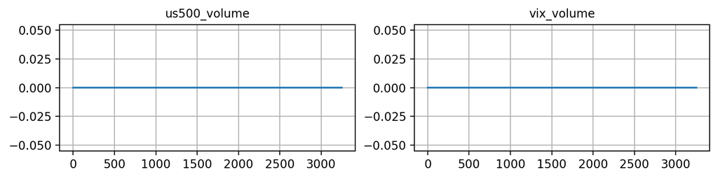

```python
# plot
fig = plt.figure(figsize = (10,2))
fig.subplots_adjust(wspace=0.2, hspace = 0.3)
ax1 =  fig.add_subplot(1, 2, 1)
ax2 =  fig.add_subplot(1, 2, 2)
ax1.plot(shiftDF[varName1])
ax1.set_title(varName1, fontsize = 10)
ax2.plot(shiftDF[varName2])
ax2.set_title(varName2, fontsize = 10)
plt.show()
```

```python
normXDF.drop(minmaxSameVarL, axis = 1, inplace = True)
minTrainXSR.drop(minmaxSameVarL, axis = 0, inplace = True)
maxTrainXSR.drop(minmaxSameVarL, axis = 0, inplace = True)
```

#### 정규화한 입력변수와 수익률 목표변수 한 데이터셋으로 생성

```python
normXrawYDF = pd.concat([normXDF, shiftYDF], axis = 1)
print(normXrawYDF.shape)
normXrawYDF.head()
```

```
(3251, 158)
```

|  | ks11_close | ks11_open | ks11_high | ks11_low | ks11_volume | ks11_change | kq11_close | kq11_open | kq11_high | kq11_low | ... | audusd_open | audusd_high | audusd_low | audusd_change | usdrub_close | usdrub_open | usdrub_high | usdrub_low | usdrub_change | return_y |
| --- | --- | --- | --- | --- | --- | --- | --- | --- | --- | --- | --- | --- | --- | --- | --- | --- | --- | --- | --- | --- | --- |
| 0 | 0.3758 | 0.2307 | 0.1799 | 0.3491 | 0.5065 | 0.9143 | 0.6942 | 0.6679 | 0.6889 | 0.6304 | ... | 0.4708 | 0.7192 | 0.3841 | 0.7700 | 0.4245 | 0.4292 | 0.4299 | 0.4683 | 0.5446 | -0.0444 |
| 1 | 0.5127 | 0.1955 | 0.3078 | 0.3546 | 0.4815 | 1.0135 | 0.7031 | 0.5990 | 0.6477 | 0.6123 | ... | 0.6071 | 0.6215 | 0.5746 | 0.4425 | 0.4646 | 0.4277 | 0.4332 | 0.5042 | 0.6774 | -0.0786 |
| 2 | 0.4260 | 0.6368 | 0.5249 | 0.6213 | 0.5195 | 0.3643 | 0.6482 | 0.7852 | 0.7137 | 0.7115 | ... | 0.5097 | 0.9495 | 0.5683 | 1.1463 | 0.4352 | 0.4643 | 0.4637 | 0.4861 | 0.4725 | -0.0571 |
| 3 | 0.1807 | 0.5404 | 0.4302 | 0.3998 | 0.4221 | 0.0795 | 0.4774 | 0.6419 | 0.6561 | 0.5289 | ... | 1.0292 | 0.9779 | 1.1206 | 0.7073 | 0.4373 | 0.4334 | 0.4343 | 0.4982 | 0.5655 | -0.0270 |
| 4 | 0.2555 | 0.4299 | 0.2969 | 0.3477 | 0.4214 | 0.6447 | 0.4494 | 0.5207 | 0.4744 | 0.4803 | ... | 1.1136 | 1.3628 | 1.1556 | 0.8467 | 0.4012 | 0.4402 | 0.4185 | 0.4567 | 0.4535 | -0.0477 |

5 rows × 158 columns

### 2.5 데이터구조변환

RNN 모델을 구현하기 위한 입력데이터(input data) 구조는 [Batch size, Time steps, Input length] 3차원 구조를 형성합니다. **Batch size**는 배치 수, **Time steps** 시퀀스(sequence)의 길이 , **Input length**는 입력 차원(input data)의 수를 의미합니다.

$$ ( Batch\;size, Time\;steps, Input\;length ) $$

```python
INTERVAL, UNIT_CELL  = 2, 5
```

타임스텝(Timestep)은 일정간격, 갯수로 구성할 수 있습니다. (명확한 용어 필요)

```python
def fnReshapeDF(normDF, yVarName, nStep, nInterval):
    '''
     Argument
    ------------ + ---------------------------
    normDF       |  적용 데이터
    yVarName     |  목표변수명
    nStep        |  시퀀스의 갯 수
    nInterval    |  시퀀스 간의 각격
    ------------ + ---------------------------
    '''
    xL = []
    yL = []
    idxDateDF = pd.DataFrame()
    startIdx = 0 + nInterval*(nStep - 1)
    endIdx = normDF.shape[0]

    normDF = normDF.copy()
    yNP = np.array(normDF.pop(yVarName))
    xNP = np.array(normDF)


    for i in range(startIdx , endIdx):
        indices = range(i, i - (nInterval*nStep), -nInterval)
        sortIdx = sorted(list(indices))

        # x
        xL.append(xNP[indices])

        # y
        yL.append(yNP[i])

        # dateDF
        tmpDateDF = dateDF.iloc[i:(i+1), :]
        idxDateDF = pd.concat([idxDateDF, tmpDateDF], axis = 0)

    idxDateDF = idxDateDF.reset_index(drop = True)

    xTotNP = np.array(xL)
    yTotNP = np.array(yL).reshape((-1, 1))
    return xTotNP, yTotNP, idxDateDF
```

```python
xNP, yNP, subDateDF = fnReshapeDF(normXrawYDF, 'return_y', UNIT_CELL, INTERVAL)
```

```python
print(xNP.shape, yNP.shape, subDateDF.shape)
```

```
(3243, 5, 157) (3243, 1) (3243, 2)
```

```python
print('training  기간 :', TRAIN_START,'~', TRAIN_END)
print('valid 기간     :', VALID_START, '~', VALID_END )
print('test 기간      :', TEST_START,'~', TEST_END )
```

```
training  기간 : 2019-03-20 ~ 2019-12-24
valid 기간     : 2019-12-25 ~ 2020-03-24
test 기간      : 2020-04-01 ~ 2020-06-30
```

```python
# date index
stTrain = subDateDF.loc[subDateDF['date_forecast']==TRAIN_START , :].index[0]
fnTrain = subDateDF.loc[subDateDF['date_forecast']==TRAIN_END , :].index[0]
stValid = subDateDF.loc[subDateDF['date_forecast']==VALID_START , :].index[0]
fnValid = subDateDF.loc[subDateDF['date_forecast']==VALID_END , :].index[0]
stTest  = subDateDF.loc[subDateDF['date_forecast']==TEST_START , :].index[0]
fnTest  = subDateDF.loc[subDateDF['date_forecast']==TEST_END , :].index[0]

trainXNP, trainYNP = xNP[stTrain:(fnTrain+1),:,:], yNP[stTrain:(fnTrain+1),:]
validXNP, validYNP = xNP[stValid:(fnValid+1),:,:], yNP[stValid:(fnValid+1),:]
testXNP, testYNP   = xNP[stTest:(fnTest+1),:,:], yNP[stTest:(fnTest+1),:]

print('Numpy Shape -train data |', trainXNP.shape, trainYNP.shape)
print('Numpy Shape -valid data |', validXNP.shape, validYNP.shape)
print('Numpy Shape - test data |', testXNP.shape, testYNP.shape)
```

```
Numpy Shape -train data | (200, 5, 157) (200, 1)
Numpy Shape -valid data | (65, 5, 157) (65, 1)
Numpy Shape - test data | (65, 5, 157) (65, 1)
```

## 3. 모델 구성

케라스는 모델을 설계하는 방식은 **Sequential API** (가장 자주 사용하는 구조인 층을 순서대로 쌓아 올린 네트워크)와 **Functional API**(완전한 임의 구조) 두 가지가 있습니다. 이번 실습에서는 RNN 모델 구성은 케라스의 **Functional API**를 사용하여 구성하였습니다. 자세한 사항은 케라스에서 제공하는 [api-guide](https://keras.io/getting-started/functional-api-guide/) 를 참고.

### 3.1 모델구조

```python
print(UNIT_CELL, trainXNP.shape[2])
```

```
5 157
```

```python
### another model
layer_input = keras.Input(shape = (UNIT_CELL,  trainXNP.shape[2]), name = 'input')
layer_rnn0 = keras.layers.SimpleRNN(units = 2**6 ,return_sequences = True, name = 'rnn_0')(layer_input)
layer_rnn1 = keras.layers.SimpleRNN(units = 2**6, name = 'rnn_1')(layer_rnn0)
layer_output = keras.layers.Dense(units = 1, activation = 'linear')(layer_rnn1)
rnn_model = keras.Model(layer_input, layer_output, name = 'RNN_MODEL')
```

```python
rnn_model.summary()
```

```
Model: "RNN_MODEL"
_________________________________________________________________
Layer (type)                 Output Shape              Param #
=================================================================
input (InputLayer)           [(None, 5, 157)]          0
_________________________________________________________________
rnn_0 (SimpleRNN)            (None, 5, 64)             14208
_________________________________________________________________
rnn_1 (SimpleRNN)            (None, 64)                8256
_________________________________________________________________
dense (Dense)                (None, 1)                 65
=================================================================
Total params: 22,529
Trainable params: 22,529
Non-trainable params: 0
_________________________________________________________________
```

### 3.2 모델 학습과정 설정

**compile** 메소드를 이용해 학습 과정을 설정합니다.필수적인 설정 인자(arguments)로는 손실 함수(loss function), 옵티마이저(optimizer), 측정지표(metircs)입니다. 각각의 사용하능한 조건은 아래와 같습니다. Keras API는 이미 optimizer, losses, metrics 를 제공하고 있습니다.

**[ Optimizers ]**

```
* SGD() (with or without momentum)
* RMSprop()
* Adam()
* etc.
```

**[ Losses ]**

```
* MeanSquaredError()
* KLDivergense()
* CosinSimilarity()
* etc.
```

**[ Metrics ]**

```
* AUC()
* Precision()
* Recall()
* etc.
```

한가지 더 부연설명을 한다면 측정지표와 손실함수의 차이점은 평가한 결과를 모델을 학습시키는데 사용하지 않는다는 점입니다.

```python
rnn_model.compile(loss = 'mse',
                   optimizer = 'rmsprop',
                   metrics = ['mse'])
```

## 4. 모델 학습

데이터, 선언된 모델을 이용하여 모델을 학습합니다. 과적합을 방지하기 위하여 validation 데이터를 이용하여 30회 validation error가 개선되지 않으면 멈추도록 합니다.

### 4.1 모델 학습

최적의 검증 손실을 얻기 위해 얼마나 많은 에포크(epoch)가 필요한지 알 수 없습니다. 또한, 과대적합이 일어날 때까지 충분한 에포크로 훈련하고 최적의 에포크를 찾아 처음부터 다시 훈련한는것은 소모적입니다. 이러한 점을 개선할 수 있는 방법으로는 검증 손실이 더 이상 향상되지 않을 때 훈련을 멈추는 방법으로 구현한 것이 콜백(callbacks)입니다.

```python
earlyStop = keras.callbacks.EarlyStopping(monitor='val_loss',
                                          mode='min',
                                          patience=30)
```

*model.fit()* 메소드는 *History* 객체를 반환합니다.해당 객체는 딕셔너리(dictionary)인 history 속성(attribute)을 갖고있습니다.

```python
HISTORY = rnn_model.fit(trainXNP, trainYNP,
          validation_data = (validXNP, validYNP),
          batch_size = 10,
          epochs = 200,
          verbose = 2,
          callbacks = [earlyStop])

# 출력물과  y구조가 다르면 모형이 작동하지 않는다. numpy shape를 충분히 숙지가 필요하다.
```

```
Train on 200 samples, validate on 65 samples
200/200 - 2s - loss: 0.5809 - mse: 0.5809 - val_loss: 0.0547 - val_mse: 0.0547
200/200 - 0s - loss: 0.0723 - mse: 0.0723 - val_loss: 0.1528 - val_mse: 0.1528
200/200 - 0s - loss: 0.0683 - mse: 0.0683 - val_loss: 0.0569 - val_mse: 0.0569
200/200 - 0s - loss: 0.0375 - mse: 0.0375 - val_loss: 0.1009 - val_mse: 0.1009
200/200 - 0s - loss: 0.0358 - mse: 0.0358 - val_loss: 0.0303 - val_mse: 0.0303
200/200 - 0s - loss: 0.0214 - mse: 0.0214 - val_loss: 0.1400 - val_mse: 0.1400
200/200 - 0s - loss: 0.0170 - mse: 0.0170 - val_loss: 0.0094 - val_mse: 0.0094
200/200 - 0s - loss: 0.0188 - mse: 0.0188 - val_loss: 0.0077 - val_mse: 0.0077
200/200 - 0s - loss: 0.0109 - mse: 0.0109 - val_loss: 0.0063 - val_mse: 0.0063
200/200 - 0s - loss: 0.0103 - mse: 0.0103 - val_loss: 0.0053 - val_mse: 0.0053
200/200 - 0s - loss: 0.0083 - mse: 0.0083 - val_loss: 0.0044 - val_mse: 0.0044
200/200 - 0s - loss: 0.0083 - mse: 0.0083 - val_loss: 0.0207 - val_mse: 0.0207
200/200 - 0s - loss: 0.0074 - mse: 0.0074 - val_loss: 0.0097 - val_mse: 0.0097
200/200 - 0s - loss: 0.0046 - mse: 0.0046 - val_loss: 0.0033 - val_mse: 0.0033
200/200 - 0s - loss: 0.0038 - mse: 0.0038 - val_loss: 0.0038 - val_mse: 0.0038
200/200 - 0s - loss: 0.0039 - mse: 0.0039 - val_loss: 0.0035 - val_mse: 0.0035
200/200 - 0s - loss: 0.0038 - mse: 0.0038 - val_loss: 0.0034 - val_mse: 0.0034
200/200 - 0s - loss: 0.0026 - mse: 0.0026 - val_loss: 0.0089 - val_mse: 0.0089
200/200 - 0s - loss: 0.0027 - mse: 0.0027 - val_loss: 0.0028 - val_mse: 0.0028
200/200 - 0s - loss: 0.0026 - mse: 0.0026 - val_loss: 0.0054 - val_mse: 0.0054
200/200 - 0s - loss: 0.0022 - mse: 0.0022 - val_loss: 0.0070 - val_mse: 0.0070
200/200 - 0s - loss: 0.0022 - mse: 0.0022 - val_loss: 0.0057 - val_mse: 0.0057
200/200 - 0s - loss: 0.0020 - mse: 0.0020 - val_loss: 0.0047 - val_mse: 0.0047
200/200 - 0s - loss: 0.0019 - mse: 0.0019 - val_loss: 0.0038 - val_mse: 0.0038
200/200 - 0s - loss: 0.0021 - mse: 0.0021 - val_loss: 0.0081 - val_mse: 0.0081
200/200 - 0s - loss: 0.0017 - mse: 0.0017 - val_loss: 0.0047 - val_mse: 0.0047
200/200 - 0s - loss: 0.0015 - mse: 0.0015 - val_loss: 0.0039 - val_mse: 0.0039
200/200 - 0s - loss: 0.0016 - mse: 0.0016 - val_loss: 0.0048 - val_mse: 0.0048
200/200 - 0s - loss: 0.0017 - mse: 0.0017 - val_loss: 0.0032 - val_mse: 0.0032
200/200 - 0s - loss: 0.0012 - mse: 0.0012 - val_loss: 0.0033 - val_mse: 0.0033
200/200 - 0s - loss: 0.0017 - mse: 0.0017 - val_loss: 0.0031 - val_mse: 0.0031
200/200 - 0s - loss: 0.0019 - mse: 0.0019 - val_loss: 0.0041 - val_mse: 0.0041
200/200 - 0s - loss: 0.0013 - mse: 0.0013 - val_loss: 0.0030 - val_mse: 0.0030
200/200 - 0s - loss: 0.0016 - mse: 0.0016 - val_loss: 0.0029 - val_mse: 0.0029
200/200 - 0s - loss: 0.0016 - mse: 0.0016 - val_loss: 0.0029 - val_mse: 0.0029
200/200 - 0s - loss: 0.0011 - mse: 0.0011 - val_loss: 0.0029 - val_mse: 0.0029
200/200 - 0s - loss: 0.0014 - mse: 0.0014 - val_loss: 0.0029 - val_mse: 0.0029
200/200 - 0s - loss: 0.0013 - mse: 0.0013 - val_loss: 0.0031 - val_mse: 0.0031
200/200 - 0s - loss: 0.0016 - mse: 0.0016 - val_loss: 0.0055 - val_mse: 0.0055
```

[output cut: 25 more lines]

```
200/200 - 0s - loss: 0.0015 - mse: 0.0015 - val_loss: 0.0044 - val_mse: 0.0044
200/200 - 0s - loss: 0.0011 - mse: 0.0011 - val_loss: 0.0034 - val_mse: 0.0034
200/200 - 0s - loss: 0.0013 - mse: 0.0013 - val_loss: 0.0026 - val_mse: 0.0026
200/200 - 0s - loss: 0.0016 - mse: 0.0016 - val_loss: 0.0061 - val_mse: 0.0061
200/200 - 0s - loss: 0.0012 - mse: 0.0012 - val_loss: 0.0092 - val_mse: 0.0092
200/200 - 0s - loss: 0.0014 - mse: 0.0014 - val_loss: 0.0028 - val_mse: 0.0028
200/200 - 0s - loss: 9.0601e-04 - mse: 9.0601e-04 - val_loss: 0.0028 - val_mse: 0.0028
200/200 - 0s - loss: 0.0013 - mse: 0.0013 - val_loss: 0.0027 - val_mse: 0.0027
200/200 - 0s - loss: 0.0013 - mse: 0.0013 - val_loss: 0.0031 - val_mse: 0.0031
200/200 - 0s - loss: 0.0015 - mse: 0.0015 - val_loss: 0.0030 - val_mse: 0.0030
200/200 - 0s - loss: 0.0012 - mse: 0.0012 - val_loss: 0.0042 - val_mse: 0.0042
200/200 - 0s - loss: 0.0017 - mse: 0.0017 - val_loss: 0.0032 - val_mse: 0.0032
200/200 - 0s - loss: 0.0010 - mse: 0.0010 - val_loss: 0.0025 - val_mse: 0.0025
200/200 - 0s - loss: 0.0012 - mse: 0.0012 - val_loss: 0.0025 - val_mse: 0.0025
200/200 - 0s - loss: 0.0014 - mse: 0.0014 - val_loss: 0.0035 - val_mse: 0.0035
```

```python
# history 객체에 history는 dict 형태로 되어있다.
HISTORY.history.keys()
```

```
dict_keys(['loss', 'mse', 'val_loss', 'val_mse'])
```

하이퍼파라미터 최적화

### 4.2 학습 시각화

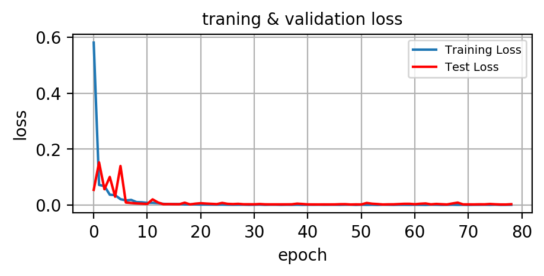

```python
plt.rcParams["figure.figsize"] = (5,2)
plt.rcParams["figure.dpi"] = 200
plt.rcParams['axes.grid'] = True
plt.plot(HISTORY.history['loss'], label = 'Training Loss')
plt.plot(HISTORY.history['val_loss'], c = 'r', label = 'Test Loss')
plt.ylabel('loss')
plt.xlabel('epoch')
plt.title('traning & validation loss', fontsize = 10)
plt.legend(loc = 'upper right', fontsize = 7)
```

#### Kospi 지수 시각화

**수익률(return_y)**을 Return(R로 표기)으로 표시하면

$$ {Return}_{t+k} = \ln Y_{t+k} - \ln Y_{t} $$$$ {R}_{t+k} = \ln \frac{ Y_{t+k} }{ Y_{t} }$$$$ e^{{R}_{t+k}} = \frac{ Y_{t+k} }{ Y_{t} } $$$$ e^{{R}_{t+k}} \times Y_{t} = Y_{t+k} $$

```python
yVar
```

```
'ks11_close'
```

```python
subRawDF = rawDF.reset_index()
subRawDF = subRawDF[['date', yVar]]
```

```python
dateL = subDateDF.loc[(subDateDF['date_forecast'] >= TEST_START ) & (subDateDF['date_forecast'] <= TEST_END ), 'date'].tolist()
dateL2 = subDateDF.loc[(subDateDF['date_forecast'] >= TEST_START ) & (subDateDF['date_forecast'] <= TEST_END ), 'date_forecast'].tolist()
```

```python
y_base   = subRawDF.loc[subRawDF['date'].isin(dateL), yVar].to_numpy().reshape(-1,1)
y_frct = subRawDF.loc[subRawDF['date'].isin(dateL2), yVar].to_numpy().reshape(-1,1)
```

## 5. 모델 평가하기

학습된 모델을 이용하여 예측값을 생성해보고, 지표값을 구하여 모델을 평가합니다.

### 5.1 test data 예측값 생성

학습한 모형을 이용해 실전으로 예측할 수 있도록 **predict** 메소드가 구현되어있습니다.

```python
rate_pred = rnn_model.predict(testXNP)
print(rate_pred.shape)
rate_pred[:6]
```

```
(65, 1)
```

```
array([[-0.02376802],
       [ 0.00888605],
       [-0.01999025],
       [-0.06481638],
       [-0.02265787],
       [-0.0358484 ]], dtype=float32)
```

```python
exp_rate_pred = np.exp(rate_pred)
y_pred = exp_rate_pred * y_base
```

#### 지수 시각화

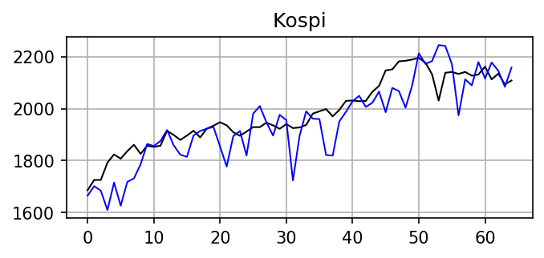

```python
#  지수(return_y)  시각화
plt.rcParams["figure.figsize"] = (5,2)
plt.rcParams["figure.dpi"] = 150
plt.rcParams['axes.grid'] = True

plt.plot(y_frct, c = 'black', linewidth = .99)
plt.plot(y_pred, c = 'blue', linewidth = .95)
plt.title('Kospi')
plt.show()
```

#### 수익률 시각화

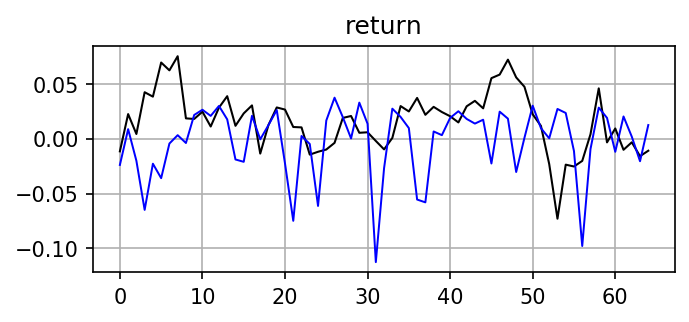

```python
#  수익률(return_y)  시각화
plt.rcParams["figure.figsize"] = (5,2)
plt.rcParams["figure.dpi"] = 150
plt.rcParams['axes.grid'] = True

plt.plot(testYNP, c = 'black', linewidth = .99)
plt.plot(rate_pred, c = 'blue', linewidth = .95)
plt.title('return')
plt.show()
```

### 5.2 모형 성능 확인

**evaluate** 메소드를 이용해 성능을 확인할 수 있습니다.

```python
rnn_model.evaluate(testXNP, testYNP)
```

```
[0.001990279017123752, 0.0019902792]
```

#### Correlation

실제수익률과 예상 수익률의 상관관계(correlation)을 계산한다.

```python
realYKDF = pd.DataFrame(testYNP, columns = ['rate_real'])
predYKDF = pd.DataFrame(rate_pred, columns = ['rate_pred'])
resultDF = pd.concat([realYKDF, predYKDF], axis = 1)
correlation = resultDF.corr()
print('[ Correlation ] ', correlation.iloc[0,1])
correlation
```

```
[ Correlation ]  0.035304097178240526
```

|  | rate_real | rate_pred |
| --- | --- | --- |
| rate_real | 1.0000 | 0.0353 |
| rate_pred | 0.0353 | 1.0000 |

#### Direction

실제 수익률과 예상 수익률의 방향성 정확도를 계산한다.

```python
directionAccL = np.sign(resultDF['rate_real']) == np.sign(resultDF['rate_pred'])
directionAcc = directionAccL.mean()
print('[ Direction Accuracy ] ', directionAcc)
```

```
[ Direction Accuracy ]  0.6153846153846154
```